# Ajax's Math Ideas

1. > I think that Base 12 is a superior number system to Base 10. You might not be able to count it on your fingers, but it’s nicer to the number 3 and it makes fractions and decimals oh so much easier.
2. > When I was four years old or younger, (specifically younger than school), I had a toy cash register that had a built-in calculator, and while I was too young to remember it, my Grandma told me I would spend *hours* with that thing. Definitely mostly addition, because that’s the only operation I knew the meaning of – like 5 plus 5 plus 5 plus 5, over and over again. (Ironically, even though this is just multiplication, I remember thinking of multiplication as like some crazy unknowable truth that even a computer couldn’t do). A noteworthy common theme of this math was often repetition, “it’s almost like you were obsessed with repetition, doing it over and over again,” recalls my Grandma. Also, I apparently had memorized the square numbers up until 100, (by trial and error with the square root button), however I have no memory of this. I would never want to hear that I should just do multiplication instead, as my Grandma recalls.
3. > In kindergarten or before, (whenever I first learned about the “=” sign), I originally thought of the equals sign as a kind of generating phenomenon, and so I came up with my own generating symbols to go in place of the equal sign. This is like inequalities meets functions, so it was kind of cool!
4. > In kindergarten or before, right when I first learned about letters and numbers, I was fascinated by the concept of *realms of numbers*, like the number line or the alphabet. I remember imagining what would happen if we could discover whole new realms of numbers, like a new number line with numbers falling under different names and doing fundamentally different things from the numbers we know, and then the process of moving from one realm to the next, until, under more advanced technology as a society, we would find a kind of transcending path that leads from the number line, through multiple new realms, and then winds up at the alphabet, like a kind of fundamental connection between them that is under the surface.
5. > When I was in first grade, my mom got me a multiplication chart for my bedroom, and while staring at it, I came up with a few intriguing properties of some of the multiples, specifically multiples of ten.
6. > In first grade, my teachers claimed that I got such high scores on exams they gave me, that they were putting me in some extra *third grade* math program. The teacher seemed pretty impressed, however I remember being far too autistic to register anything about the validity and end result of this extra program.
7. > In second or third grade, having learned about addition and subtraction, I wanted a way to figure out how to concatenate numbers. While I didn’t actually arrive at the formula until I thought about the problem again in 10th grade, I had some interesting thoughts involving an *AB* table, (which is the concatenation equivalent of a multiplication table), and maybe even an inverse function to concatenation as subtraction is to addition.
8. > In third grade, I took a huge piece of paper and wrote a 30 by 30 multiplication table, since I loved the 12 by 12 one I learned in school so much. I remember it being like a rush, it was so exciting to learn / make. It took hours, and I don’t even think I finished it, but I definitely got most of it filled in.
9. > Fourth grade is when I consciously fell in love with mathematics.
10. > In fourth grade, directly after learning both fractions and decimals, I made my own number line of all the fractions and decimals I could think of, plotting fractions above and decimals below. I remember it being staggeringly complicated for that age. In fourth grade, I came up with a trick to take each next reciprocal of a power of 2 manually. I got as far as 1/32 = 0.03125.
    1. > Here is a whiteboard image where I wrote some of these results:

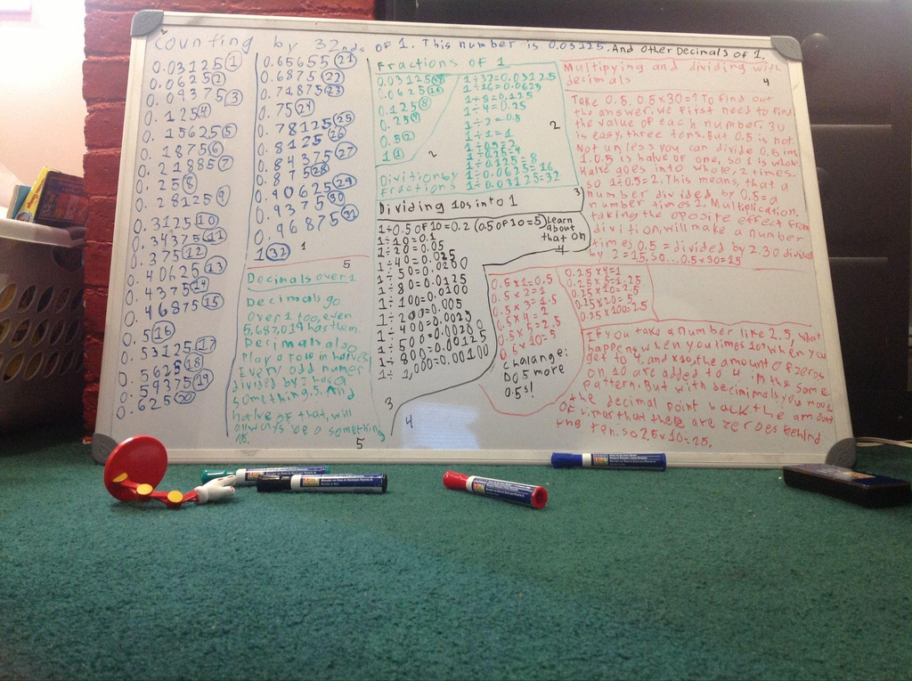